# Chapter 5 MAG catalogue

An overview of the recovered MAGs: circular phylogeny with phylum ring, genome quality and size rings, and “new species” flags; summaries of MAG sizes and quality; and a high-level functional overview including a t-SNE of genome functions.

## 5.1 Microbiota data

**Note:** Load all required data objects including genome metadata, phylogenetic tree, GIFT annotations, and color schemes from the RData file created in the data preparation chapter.

```r
load("data/data.Rdata")
```

**Note:** Filter out sample EHI01340 from the metadata. This sample was removed because it could not be mapped to MAGs, ensuring consistency across downstream analyses.

```r
sample_metadata<- sample_metadata %>% filter(sample!="EHI01340")
```

*EHI01340 sample has been removed because of inability to map MAGS*

### 5.1.1 Genome phylogeny

**Note:** Prepare data for circular phylogenetic tree visualization. Load phylum color scheme from EHI taxonomy repository and create a phylum heatmap matrix ordered to match the tree tip labels. Generate a new species flag table identifying MAGs with incomplete species assignments (species == “s__“). Create an ultrametric tree layout for circular visualization.

```r
# Generate the phylum color heatmap
phylum_heatmap <- read_tsv("https://raw.githubusercontent.com/earthhologenome/EHI_taxonomy_colour/main/ehi_phylum_colors.tsv") %>%
    right_join(genome_metadata, by=join_by(phylum == phylum)) %>%
    filter(genome %in% genome_tree$tip.label) %>%
    arrange(match(genome, genome_tree$tip.label)) %>%
    select(genome,phylum) %>%
    mutate(phylum = factor(phylum, levels = unique(phylum))) %>%
    column_to_rownames(var = "genome")

# Generate new species table
newspecies_table <- genome_metadata %>%
  filter(genome %in% genome_tree$tip.label) %>%
  mutate(newspecies=ifelse(species=="s__","Y","N")) %>%
  select(genome,newspecies) %>%
  column_to_rownames(var = "genome")

# Generate  basal tree
circular_tree <- force.ultrametric(genome_tree, method="extend") %>% # extend to ultrametric for the sake of visualisation
    ggtree(., layout="fan", open.angle=10, size=0.5)
```

```
## *                          Note:                              *
## *    force.ultrametric does not include a formal method to    *
## *    ultrametricize a tree & should only be used to coerce    *
## *   a phylogeny that fails is.ultrametric due to rounding --  *
## *    not as a substitute for formal rate-smoothing methods.   *
```

**Note:** Build the circular phylogenetic tree with multiple annotation rings. Add phylum ring as a heatmap using EHI color scheme, genome quality ring showing completeness (bar length) colored by contamination level, new species flag ring indicating MAGs with incomplete species assignments, and genome size ring showing relative genome lengths. Add text labels to identify each ring. Rotate and open the tree for optimal visualization.

```r
# Add phylum ring
# circular_tree <- gheatmap(circular_tree, phylum_heatmap, offset=0.55, width=0.1, colnames=FALSE) +
#         scale_fill_manual(values=phylum_colors) +
#         geom_tiplab2(size=1, hjust=-0.1) +
#         theme(legend.position = "none", plot.margin = margin(0, 0, 0, 0), panel.margin = margin(0, 0, 0, 0))
circular_tree <- gheatmap(circular_tree, phylum_heatmap, offset=0.05, width=0.05, colnames=FALSE) +
        scale_fill_manual(values=phylum_colors) +
  labs(fill="Phylum")
        #theme(legend.position = "none", plot.margin = margin(0, 0, 0, 0), panel.margin = margin(0, 0, 0, 0))

# Flush color scale to enable a new color scheme in the next ring
circular_tree <- circular_tree + new_scale_fill()

# Prepare genome_metadata filtered to tree tips for geom_fruit
# geom_fruit expects 'label' column to match tree tip labels
genome_metadata_filtered <- genome_metadata %>%
  filter(genome %in% genome_tree$tip.label) %>%
  mutate(label = genome)

# Add completeness ring
circular_tree <- circular_tree +
        new_scale_fill() +
        scale_fill_gradient(low = "#d1f4ba", high = "#f4baba") +
        geom_fruit(
                data = genome_metadata_filtered,
                geom = geom_bar,
                mapping = aes(x = completeness, y = label, fill = contamination),
                offset = 0.24,
                pwidth = 0.1,
                orientation = "y",
                stat = "identity") +
  labs(fill="Contamination")

# Add genome-size ring
circular_tree <-  circular_tree + new_scale_fill()

circular_tree <- gheatmap(circular_tree, newspecies_table, offset=0.3, width=0.05, colnames=FALSE) +
  scale_fill_manual(values=c("#f4f4f4","#74C8AE"))+
  labs(fill="New species")
        #theme(legend.position = "none", plot.margin = margin(0, 0, 0, 0), panel.margin = margin(0, 0, 0, 0))


circular_tree <-  circular_tree +
  geom_fruit(
    data = genome_metadata_filtered,
    geom = geom_bar,
    mapping = aes(x = length, y = label),
    fill = "#1e6e55",
    offset = 0.05,
    orientation = "y",
    stat = "identity")


# Add text
circular_tree <-  circular_tree +
        annotate('text', x=3.1, y=0, label='            Phylum', family='arial', size=3.5) +
        annotate('text', x=3.7, y=0, label='                         Genome quality', family='arial', size=3.5) +
        annotate('text', x=4.1, y=0, label='                     Genome size', family='arial', size=3.5) +
        annotate('text', x=3.4, y=0, label='                     New species', family='arial', size=3.5)

#Plot circular tree
circular_tree %>% open_tree(30) %>% rotate_tree(90)
```

[output not shown]

### 5.1.2 Taxonomy overview

**Note:** Calculate the number of MAGs per phylum and compute the percentage distribution. Display results in a formatted table sorted by percentage in descending order to show which phyla dominate the MAG collection.

```r
tax_mag <-genome_metadata %>%
  group_by(phylum) %>%
  summarise(mag_n=n())

tax_mag %>%
  mutate(percentage_mag=round(mag_n*100/sum(mag_n), 2)) %>%
  arrange(-percentage_mag) %>%
  tt()
```

| phylum | mag_n | percentage_mag |
| --- | --- | --- |
| p__Bacillota_A | 1440 | 79.25 |
| p__Bacillota | 94 | 5.17 |
| p__Cyanobacteriota | 82 | 4.51 |
| p__Bacteroidota | 71 | 3.91 |
| p__Pseudomonadota | 34 | 1.87 |
| p__Actinomycetota | 25 | 1.38 |
| p__Synergistota | 17 | 0.94 |
| p__Campylobacterota | 15 | 0.83 |
| p__Thermoplasmatota | 12 | 0.66 |
| p__Desulfobacterota | 8 | 0.44 |
| p__Bacillota_C | 7 | 0.39 |
| p__Verrucomicrobiota | 6 | 0.33 |
| p__Spirochaetota | 4 | 0.22 |
| p__Bacillota_B | 1 | 0.06 |
| p__Methanobacteriota | 1 | 0.06 |

**Note:** Calculate corrected genome size by dividing observed length by completeness percentage and multiplying by 100. This estimates the true genome size accounting for incomplete assembly. Arrange genomes by completeness for downstream analysis.

```r
genome_metadata <-genome_metadata %>%
  mutate(corrected_size=ifelse(completeness > 0, 100*length/completeness, NA)) %>%
  arrange(completeness)
```

**Note:** Calculate the mean corrected genome size across all MAGs. This provides a summary statistic for the average genome size in the collection, accounting for assembly completeness.

```r
genome_metadata %>%
  summarise(Average_corrected_size=mean(corrected_size))
```

```
## # A tibble: 1 × 1
##   Average_corrected_size
##                    <dbl>
## 1               2305214.
```

### 5.1.4 Genome quality

**Note:** Calculate summary statistics for genome quality metrics (completeness and contamination). Compute mean and standard deviation for each metric, then format as “mean ± SD” strings for display in a formatted table. This provides an overview of overall MAG quality in the collection.

```r
genome_metadata %>%
    summarise(completeness_mean=mean(completeness) %>% round(2) %>% as.character(),
              completeness_sd=sd(completeness) %>% round(2) %>% as.character(),
              contamination_mean=mean(contamination) %>% round(2),
              contamination_sd=sd(contamination) %>% round(2)) %>%
    unite("Completeness",completeness_mean, completeness_sd, sep = " ± ", remove = TRUE) %>%
    unite("Contamination",contamination_mean, contamination_sd, sep = " ± ", remove = TRUE) %>%
    tt()
```

| Completeness | Contamination |
| --- | --- |
| 79.4 ± 16.77 | 2.79 ± 2.58 |

MAG quality landscape: scatter shows completeness (x) vs contamination (y), point size ∝ genome length and colour = phylum; minimalist side boxplots summarise each metric.

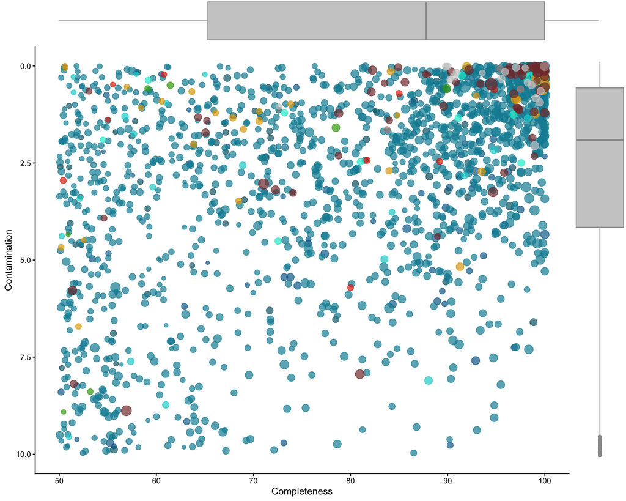

```r
#Generate quality biplot
genome_biplot <- genome_metadata %>%
  select(c(genome,domain,phylum,completeness,contamination,length)) %>%
  arrange(match(genome, rev(genome_tree$tip.label))) %>% #sort MAGs according to phylogenetic tree
  ggplot(aes(x=completeness,y=contamination,size=length,color=phylum)) +
              geom_point(alpha=0.7) +
                    ylim(c(10,0)) +
                    scale_color_manual(values=phylum_colors) +
                    labs(y= "Contamination", x = "Completeness") +
                    theme_classic() +
                    theme(legend.position = "none")

#Generate contamination boxplot
genome_contamination <- genome_metadata %>%
            ggplot(aes(y=contamination)) +
                    ylim(c(10,0)) +
                    geom_boxplot(colour = "#999999", fill="#cccccc") +
                    theme_void() +
                    theme(legend.position = "none",
                        axis.title.x = element_blank(),
                        axis.title.y = element_blank(),
                        axis.text.y=element_blank(),
                        axis.ticks.y=element_blank(),
                        axis.text.x=element_blank(),
                        axis.ticks.x=element_blank(),
                        plot.margin = unit(c(0, 0, 0.40, 0),"inches")) #add bottom-margin (top, right, bottom, left)

#Generate completeness boxplot
genome_completeness <- genome_metadata %>%
        ggplot(aes(x=completeness)) +
                xlim(c(50,100)) +
                geom_boxplot(colour = "#999999", fill="#cccccc") +
                theme_void() +
                theme(legend.position = "none",
                    axis.title.x = element_blank(),
                    axis.title.y = element_blank(),
                    axis.text.y=element_blank(),
                    axis.ticks.y=element_blank(),
                    axis.text.x=element_blank(),
                    axis.ticks.x=element_blank(),
                    plot.margin = unit(c(0, 0, 0, 0.50),"inches")) #add left-margin (top, right, bottom, left)

#Render composite figure
grid.arrange(grobs = list(genome_completeness,genome_biplot,genome_contamination),
        layout_matrix = rbind(c(1,1,1,1,1,1,1,1,1,1,1,1),
                              c(2,2,2,2,2,2,2,2,2,2,2,3),
                              c(2,2,2,2,2,2,2,2,2,2,2,3),
                              c(2,2,2,2,2,2,2,2,2,2,2,3),
                              c(2,2,2,2,2,2,2,2,2,2,2,3),
                              c(2,2,2,2,2,2,2,2,2,2,2,3),
                              c(2,2,2,2,2,2,2,2,2,2,2,3),
                              c(2,2,2,2,2,2,2,2,2,2,2,3),
                              c(2,2,2,2,2,2,2,2,2,2,2,3),
                              c(2,2,2,2,2,2,2,2,2,2,2,3),
                              c(2,2,2,2,2,2,2,2,2,2,2,3),
                              c(2,2,2,2,2,2,2,2,2,2,2,3)))
```

### 5.1.5 Functional overview

*Predicted genes*

**Note:** Load genome annotations and count the total number of predicted genes across all MAGs. This provides a summary of the total gene content in the MAG collection.

```r
genome_annotations <- read_tsv("data/genome_annotations.tsv.xz") %>%
    rename(gene=1, genome=2, contig=3)

# Predicted genes
pred_genes <- genome_annotations %>%
  nrow()

cat(pred_genes)
```

```
## 1736968
```

*Number of annotated genes and percentages*

**Note:** Calculate the number of genes with at least one functional annotation (KEGG, Pfam, or CAZy). Compute the percentage of annotated genes relative to total predicted genes. This metric indicates the proportion of genes that could be functionally characterized.

```r
# Some annotation
genome_annota <- genome_annotations %>%
  filter(if_any(c(kegg_id, pfam_hits, cazy_hits), ~ !is.na(.))) %>%
  nrow()

cat(genome_annota)
```

```
## 1335016
```

```r
# Some annotation percentage
genome_annota*100/pred_genes
```

```
## [1] 76.85899
```

*Number of KEGG annotated genes and percentages*

**Note:** Calculate the number of genes with KEGG pathway annotations and compute the percentage relative to all annotated genes. This provides insight into the proportion of functionally annotated genes that have pathway assignments.

```r
# KEGG annotation
kegg_annota <- genome_annotations %>%
  filter(!is.na(kegg_id)) %>%
  nrow()
cat(kegg_annota)
```

```
## 791897
```

```r
# KEGG annotation percentage
kegg_annota*100/genome_annota
```

```
## [1] 59.31742
```

**Note:** Create a comprehensive functional heatmap visualization combining phylogenetic tree, phylum colors, GIFT element profiles, and genome completeness. Generate an ultrametric tree layout, add phylum color heatmap next to tree tips, add functional element heatmap showing GIFT profiles for each genome, and add completeness barplots. Save the composite figure to PDF for publication.

```r
# Generate  basal tree
function_tree <- force.ultrametric(genome_tree, method="extend") %>%
                ggtree(., size = 0.3)

#Add phylum colors next to the tree tips
function_tree <- gheatmap(function_tree, phylum_heatmap, offset=0, width=0.1, colnames=FALSE) +
            scale_fill_manual(values=phylum_colors) +
            labs(fill="Phylum")

#Reset fill scale to use a different colour profile in the heatmap
function_tree <- function_tree + new_scale_fill()

#Add functions heatmap
function_tree <- gheatmap(function_tree, function_table, offset=0.5, width=3.5, colnames=FALSE) +
            vexpand(.08) +
            coord_cartesian(clip = "off") +
            scale_fill_gradient(low = "#f4f4f4", high = "steelblue", na.value="white") +
            labs(fill="GIFT")

#Reset fill scale to use a different colour profile in the heatmap
function_tree <- function_tree + new_scale_fill()

# Add completeness barplots
function_tree <- function_tree +
            geom_fruit(data=genome_metadata,
            geom=geom_bar,
            grid.params=list(axis="x", text.size=2, nbreak = 1),
            axis.params=list(vline=TRUE),
            mapping = aes(x=length, y=genome, fill=completeness),
                 offset = 3.8,
                 orientation="y",
                 stat="identity") +
            scale_fill_gradient(low = "#cf8888", high = "#a2cc87") +
            labs(fill="Genome\ncompleteness")

function_tree

ggsave("function_tree.pdf", width = 6, height = 12, units = "in")
```

[output not shown]

### 5.1.6 Functional ordination

t-SNE ordination of genome functional profiles (GIFT elements). Points are MAGs; colour = phylum, size ∝ genome length.

**Note:** Perform t-SNE dimensionality reduction on GIFT element profiles to visualize functional relationships between MAGs in two-dimensional space. Generate t-SNE coordinates, join with genome metadata to add phylum and size information, and create a scatter plot colored by phylum with point sizes proportional to genome length. This visualization reveals clusters of MAGs with similar functional profiles, independent of phylogenetic relationships.

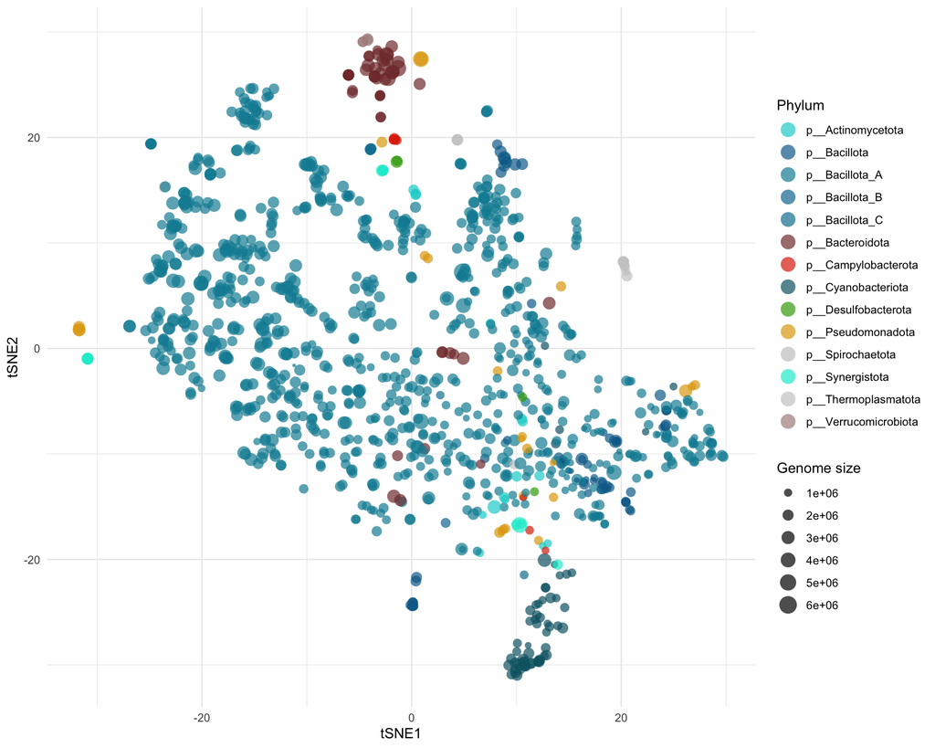

```r
# Generate the tSNE ordination
tSNE_function <- Rtsne(X=function_table, dims = 2, check_duplicates = FALSE)

# Plot the ordination
function_ordination <- tSNE_function$Y %>%
                as.data.frame() %>%
                mutate(genome=rownames(function_table)) %>%
                inner_join(genome_metadata, by="genome") %>%
                rename(tSNE1="V1", tSNE2="V2") %>%
                select(genome,phylum,tSNE1,tSNE2, length) %>%
                ggplot(aes(x = tSNE1, y = tSNE2, color = phylum, size=length))+
                            geom_point(shape=16, alpha=0.7) +
                            scale_color_manual(values=phylum_colors) +
                            theme_minimal() +
                labs(color="Phylum", size="Genome size") +
                guides(color = guide_legend(override.aes = list(size = 5))) # enlarge Phylum dots in legend

function_ordination
```